# Hypertension and diabetes among Maldives women in 2016

Surattana Boonsai

2025-06-27

# 1. Introduction

Hypertension and diabetes are major non-communicable diseases (NCDs) that significantly contribute to the global burden of disease. They are leading risk factors for cardiovascular diseases, kidney failure, and premature mortality worldwide. In low- and middle-income countries, the prevalence of these conditions is rising due to aging populations, urbanization, unhealthy diets, and physical inactivity.

# 2. Prevalence of hypertension and diabetes among women in Maldives in 2016

This section presents the prevalence of hypertension and diabetes among women in the Maldives, based on the 2016 Demographic and Health Survey (DHS) data.

**Fig.1** Hypertension and diabetes status among Maldives women in 2016

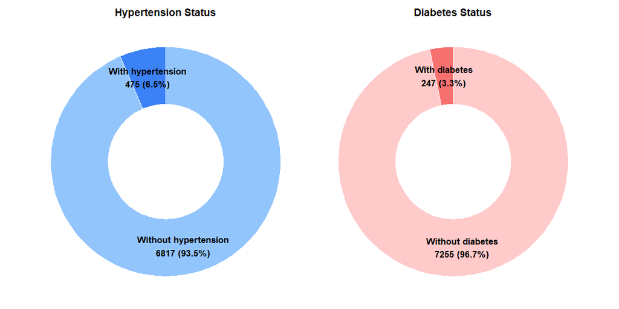

According to the side-by-side donut chart (Fig. 1), approximately 6.5% (475 women) in the Maldives have hypertension, while 3.3% (247 women) have diabetes.

Next, the Venn diagram presents the percentage of women with hypertension and/or diabetes, highlighting the proportion affected by one or both conditions.

**Fig.2** Venn diagram showing Percentage of women with hypertension and/or diabetes.

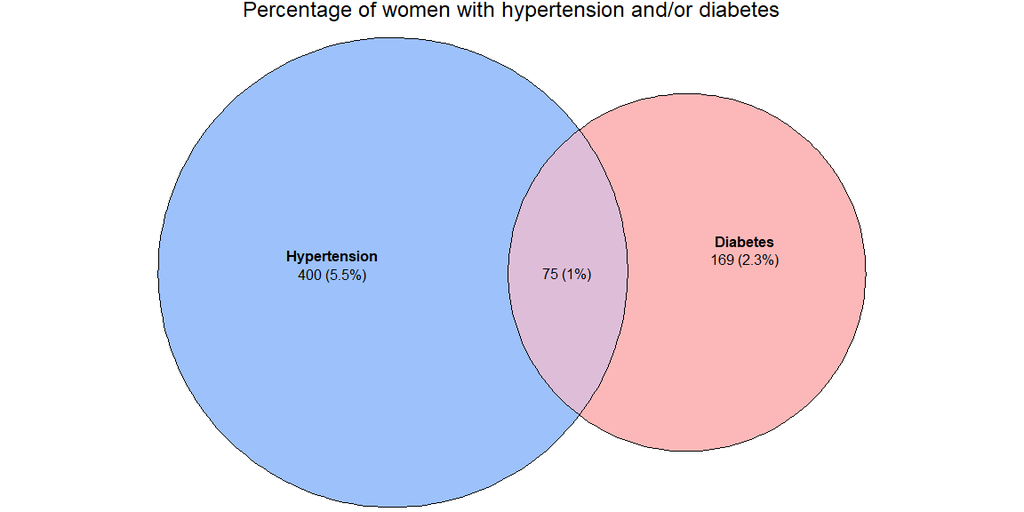

The Fig. 2 indicates that while some women face both hypertension and diabetes (1%), most are living with only one of these conditions. This suggests the importance of targeted prevention and management strategies for each disease, as well as integrated care for those with both.

# 3. Demographic information of interviewees

## Demographic profile of interviewees

This report uses data from the Demographic and Health Survey (DHS) of women in the Maldives. It summarizes key background characteristics of the respondents, including age group, educational attainment, place of residence, region, occupation, and smoking behavior. The table below presents the basic demographic and socioeconomic information of the interviewees.

**Table. 1** Table of interviewees demographic information

| Age Group | With Hypertension | Without Hypertension | With Diabetes | Without Diabetes |
| --- | --- | --- | --- | --- |
| 15-19 | 3.6% (17) | 13.3% (904) | 2.0% (5) | 13.0% (916) |
| 20-24 | 7.2% (34) | 15.0% (1,023) | 2.0% (5) | 15.0% (1,052) |
| 25-29 | 13.1% (62) | 19.3% (1,310) | 9.8% (24) | 19.2% (1,352) |
| 30-34 | 16.2% (77) | 18.8% (1,281) | 17.6% (43) | 18.7% (1,313) |
| 35-39 | 14.7% (70) | 13.9% (947) | 16.0% (39) | 13.9% (976) |
| 40-44 | 20.6% (98) | 10.6% (720) | 26.2% (64) | 10.7% (756) |
| 45+ | 24.6% (117) | 9.0% (614) | 26.2% (64) | 9.5% (670) |

| Educational Level | With Hypertension | Without Hypertension | With Diabetes | Without Diabetes |
| --- | --- | --- | --- | --- |
| No education | 7.8% (37) | 4.4% (296) | 11.5% (28) | 4.3% (306) |
| Primary | 45.7% (217) | 25.3% (1,720) | 48.4% (118) | 25.9% (1,821) |
| Secondary | 34.9% (166) | 54.2% (3,686) | 31.6% (77) | 53.7% (3,777) |
| Higher | 11.6% (55) | 16.1% (1,097) | 8.6% (21) | 16.1% (1,131) |

| Region | With Hypertension | Without Hypertension | With Diabetes | Without Diabetes |
| --- | --- | --- | --- | --- |
| Malé_Capital city | 20.2% (96) | 12.8% (868) | 19.3% (47) | 13.0% (917) |
| North Region | 14.1% (67) | 17.0% (1,153) | 14.3% (35) | 16.8% (1,185) |
| North Central | 11.6% (55) | 19.4% (1,316) | 13.9% (34) | 19.0% (1,336) |
| Central Region | 21.3% (101) | 12.5% (848) | 16.4% (40) | 12.9% (909) |
| South Central | 18.9% (90) | 21.8% (1,479) | 19.3% (47) | 21.7% (1,524) |
| South Region | 13.9% (66) | 16.7% (1,135) | 16.8% (41) | 16.5% (1,164) |

### Highlight of the Table 1

#### Age Group Distribution Table

The table shows that the prevalence of hypertension and diabetes increases with age. Individuals aged 40 years and above have the highest prevalence of both conditions, with hypertension rates peaking at 24.6% among those aged 45+ and diabetes rates reaching 26.2% in the 40–44 and 45+ groups. Younger age groups show notably lower prevalence.

#### Region Distribution Table

Regional differences in hypertension and diabetes prevalence are evident. The Central Region and Malé (Capital City) show the highest hypertension rates (21.3% and 20.2%, respectively). Diabetes prevalence is relatively high in South Central and Malé, each reporting 19.3%. Other regions show moderate to lower prevalence levels.

### Residence Distribution

This chart presents the distribution of disease status among women with hypertension and/or diabetes in the Maldives, classified by their place of residence (urban or rural). The disease groups include those with hypertension only, diabetes only, and both conditions.

**Fig. 3** Distribution of Individuals with Hypertension and/or Diabetes by Residence

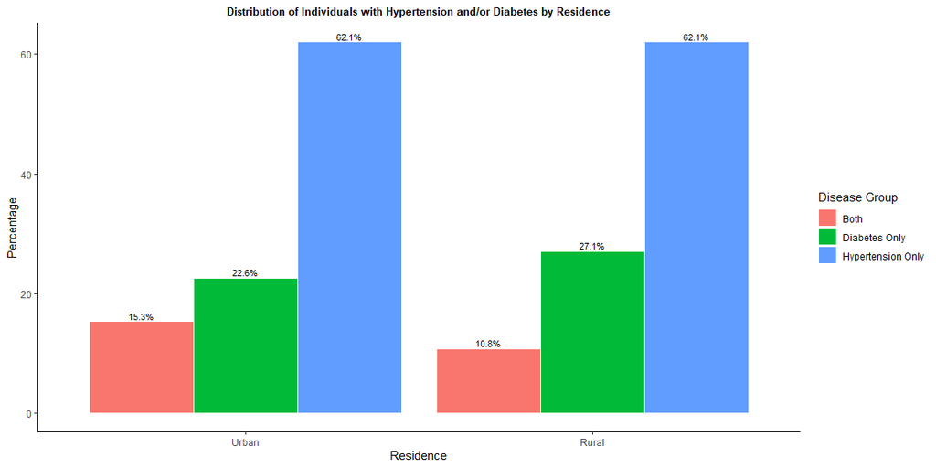

### Occupation Distribution

This chart compares the distribution of occupations among individuals with hypertension, diabetes, or both. It highlights how these conditions are represented across different occupational groups.

**Fig. 4** Occupation distribution by disease group

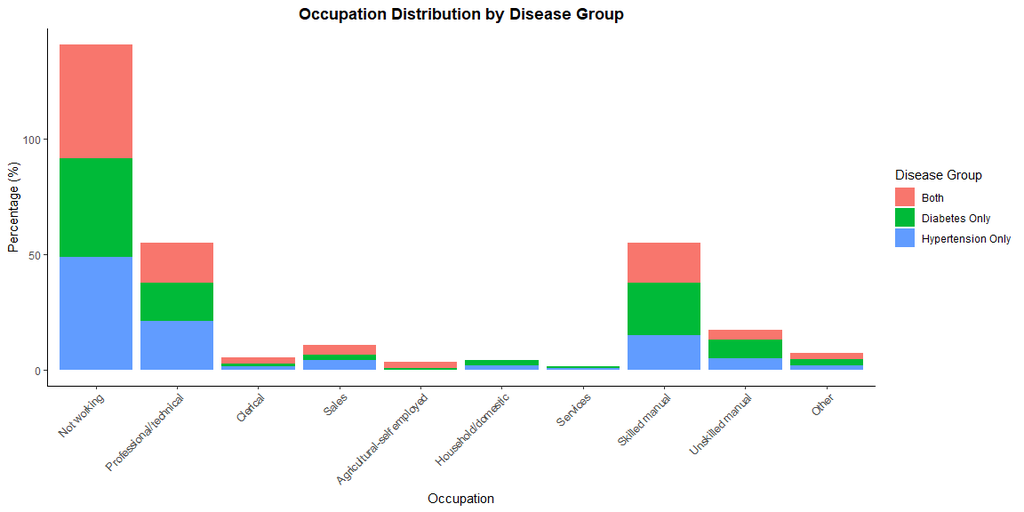

The chart shows variations in disease prevalence across occupations. Notably, individuals who are unemployed, professionals, and skilled manual workers have higher proportions of both hypertension and diabetes. These findings suggest potential occupational health risks and may help guide targeted health interventions.

### Smoking behavior with hypertension and diabetes status

The chart below presents the distribution of smoking behavior among individuals with and without hypertension and diabetes. This visualization helps compare smoking prevalence across different disease groups.

**Fig. 5** Smoking Behavior by Hypertension and Diabetes Status

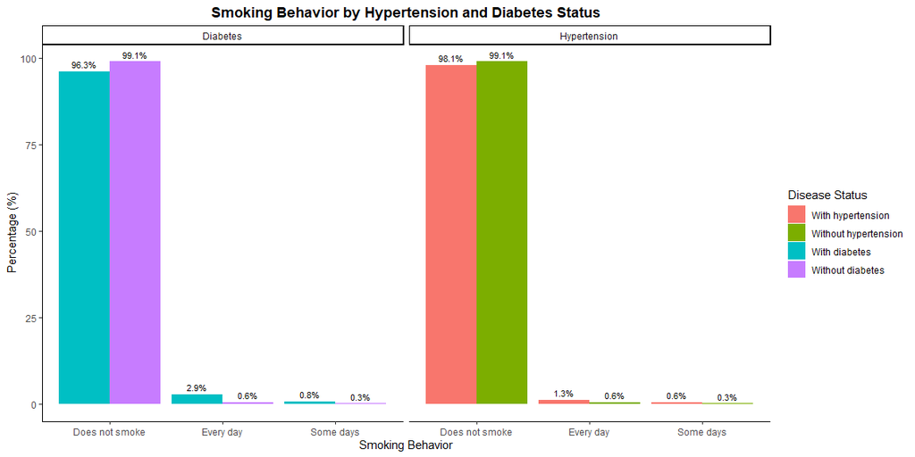

According to the Fig. 5, most respondents in all groups reported not smoking, with over 96% in every group being non-smokers. A slightly higher proportion of individuals with diabetes and hypertension reported current smoking compared to those without these conditions, though the difference is small.

# 4. Capacity to control both hypertension and diabetes

In this study, we examine several key factors that may influence the ability to manage hypertension and diabetes, including health insurance coverage, wealth status, and strategies for controlling hypertension.

## 4.1 Health insurance status

This section presents the distribution of health insurance coverage among individuals with hypertension and/or diabetes.

**Fig. 6** Health insurance status by disease group

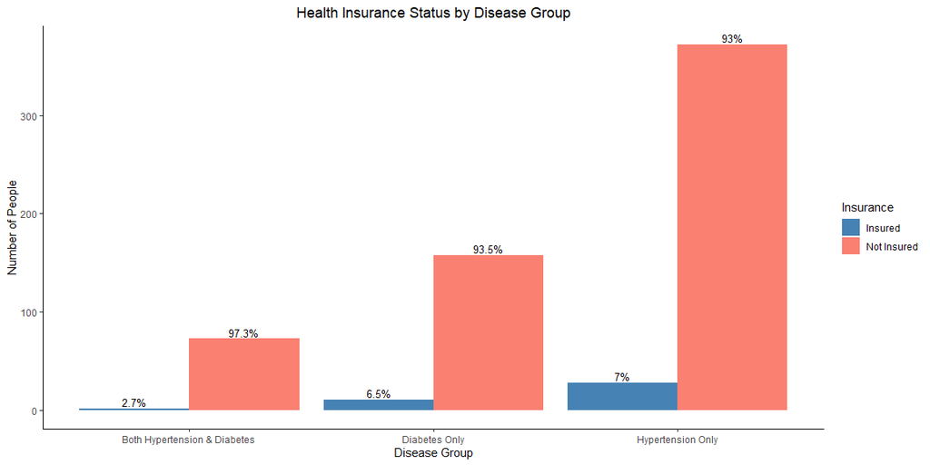

According to Fig. 6, individuals with hypertension have the highest insurance coverage (7%), followed by those with diabetes only (6.5%). In contrast, individuals with both hypertension and diabetes show the lowest insurance coverage rate (2.7%). Overall, insurance coverage across all groups remains low, which may pose challenges for effective disease management and control.

## 4.2 Wealth index distribution among the group

Another important factor influencing health outcomes is economic status. This section presents the distribution of the wealth index among individuals with hypertension and/or diabetes.

**Fig. 7** Wealth index distribution among the group

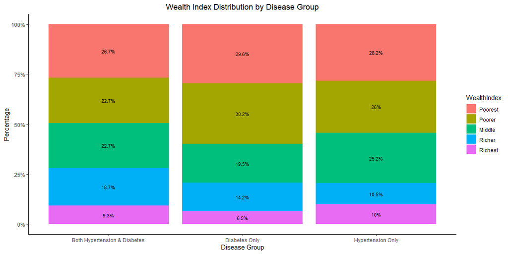

## 4.3 Strategies to control hypertension and diabetes

The graph compares the use of different lifestyle and treatment factors in managing hypertension and diabetes.

**Fig. 8** Strategies used to control hypertension and diabetes

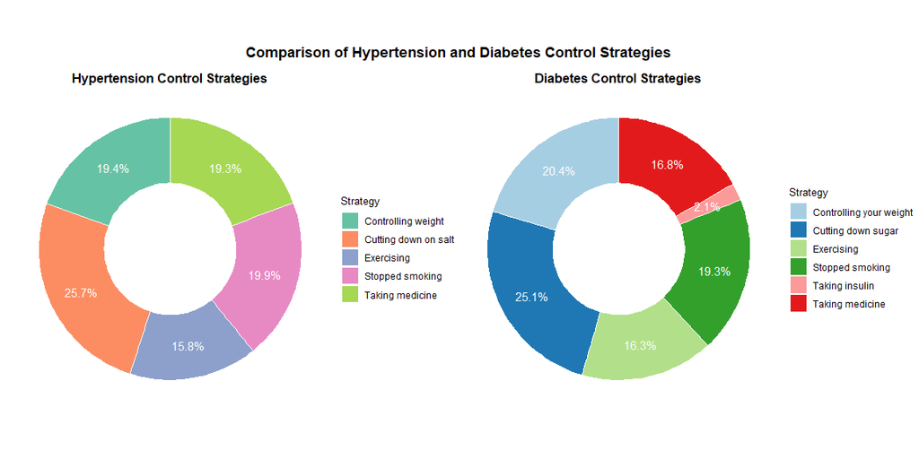

This graph shows that lifestyle modifications are the most common strategies for managing hypertension and diabetes. For hypertension, “cutting down on salt” (25.7%) leads, followed by “stopped smoking” (19.9%) and “controlling weight” (19.4%). In diabetes, “cutting down sugar” (25.1%) and “controlling your weight” (20.4%) are most common. The results highlight differences in management approaches between the two conditions.

# 5. Conclusion

## Prevalence and demographic information of individual with hypertension and diabetes.

This analysis shows that hypertension and diabetes are more common among older women in Maldives in 2016, especially those over 40. Women with lower education levels and those living in certain regions, such as Malé and the Central Region, also have higher rates of these conditions.

Most women have only one of these conditions, with few experiencing both. Factors like occupation, place of residence, and smoking habits also affect the risk of hypertension and diabetes.

These findings highlight the need for focused health programs for older women, those with lower education, and people living in high-risk areas.

## Capacity to control hypertension and diabetes

In summary, many women in Maldives with hypertension and diabetes have low insurance coverage and face economic challenges, which may limit their access to proper healthcare. Most people rely on lifestyle changes—like adjusting their diet, controlling weight, or exercising—to manage their conditions, while fewer use medications. These findings highlight the need to improve healthcare access and support people in managing their health through both medical care and healthy habits.